# Buckling-Constrained Truss Optimization with SDP Constraints

## Description

This tutorial demonstrates buckling-constrained topology optimization on a truss structure. The goal is to minimize compliance while ensuring the combined stiffness matrix `K + c·Kσ` remains positive semidefinite — i.e., the structure does not buckle under the applied load scaled by buckling factor `c`.

We use differentiable building blocks (`ElementK`, `AssembleK`, `TrussElementKσ`, `apply_boundary_with_zerodiag!`, `apply_boundary_with_meandiag!`) and enforce the PSD constraint via semidefinite programming (SDP) using NonconvexSemidefinite.jl with an IPM barrier method.

## Setup

```julia
using TopOpt, LinearAlgebra, Zygote
using Nonconvex, NonconvexSemidefinite, NonconvexIpopt
```

## Load Truss Geometry

Download the truss geometry file: tim_2d.json.

```julia
ndim = 2
node_points, elements, mats, crosssecs, fixities, load_cases = load_truss_json(
    joinpath(@__DIR__, "tim_$(ndim)d.json")
)
ndim, nnodes, ncells = length(node_points[1]), length(node_points), length(elements)
loads = load_cases["0"]
problem = TrussProblem(
    Val{:Linear}, node_points, elements, loads, fixities, mats, crosssecs
)
```

## Parameter Settings

```julia
xmin = 0.0001   # minimum density
p = 1.0         # SIMP penalty exponent
V = 0.5         # volume fraction
x0 = fill(1.0, ncells)  # initial design (all solid)
```

## FEA Solver and Buckling Helpers

```julia
solver = FEASolver(DirectSolver, problem; xmin=xmin)
ch = problem.ch

comp = TopOpt.Compliance(solver)
dp = TopOpt.Displacement(solver)
assemble_k = TopOpt.AssembleK(problem)
element_k = ElementK(solver)
truss_element_kσ = TrussElementKσ(problem, solver)
```

Five differentiable building blocks: 1. **Compliance** — objective to minimize 2. **Displacement** — solves `K·u = f` for displacements 3. **ElementK** — per-element stiffness matrices 4. **AssembleK** — assembles global sparse matrix 5. **TrussElementKσ** — geometric (stress) stiffness matrices

## Buckling Constraint Function

```julia
c = 0.0001  # buckling load multiplier (below critical load)

function buckling_matrix_constr(x)
    xd = PseudoDensities(x)
    u = dp(xd)
    Kes = element_k(xd)
    K = assemble_k(Kes)
    K = apply_boundary_with_meandiag!(K, ch)
    Kσs = truss_element_kσ(u, xd)
    Kσ = assemble_k(Kσs)
    Kσ = apply_boundary_with_zerodiag!(Kσ, ch)
    return Array(K + c * Kσ)
end
```

The constraint returns the combined matrix `K + c·Kσ` which must be PSD (all eigenvalues ≥ 0).

## Check Initial Design

```julia
S0 = buckling_matrix_constr(x0)
println("Initial design minimum eigenvalue: $(minimum(eigen(S0).values))")
```

```
Initial design minimum eigenvalue: 0.000455960618857254
```

The initial all-solid design should have positive eigenvalues (stable).

## Volume Constraint

```julia
vol_constr(x) = sum(x) / length(x) - V
```

## Compliance-Only Optimization (Baseline)

```julia
obj = x -> comp(PseudoDensities(x))

model = Model(obj)
addvar!(model, zeros(length(x0)), ones(length(x0)))
add_ineq_constraint!(model, vol_constr)

alg = MMA87()
options = MMAOptions(; maxiter=20, tol=Tolerance(; kkt=1e-4))
r1 = optimize(model, alg, x0; options=options)

println("Compliance-only result:")
println("  obj = $(obj(r1.minimizer))")
println("  vol = $(vol_constr(r1.minimizer))")
```

```
[ Info:   iter       obj      Δobj  violation  kkt_residual
[ Info:      0   4.3e+00       Inf   5.0e-01   5.0e-01
[ Info:      1   7.8e+00   3.5e+00   5.0e-02   4.3e+32
[ Info:      2   7.5e+00   3.8e-01   0.0e+00   6.5e-01
[ Info:      3   6.3e+00   1.2e+00   0.0e+00   3.0e-01
[ Info:      4   5.4e+00   8.8e-01   0.0e+00   9.6e-01
[ Info:      5   4.9e+00   4.8e-01   0.0e+00   1.5e-01
[ Info:      6   4.9e+00   5.3e-03   0.0e+00   4.8e-02
[ Info:      7   4.9e+00   5.8e-04   0.0e+00   9.4e-01
[ Info:      8   4.9e+00   1.2e-02   0.0e+00   7.8e-02
[ Info:      9   4.9e+00   9.3e-03   0.0e+00   9.6e-01
[ Info:     10   4.9e+00   1.3e-04   0.0e+00   5.6e-01
[ Info:     11   4.9e+00   1.6e-02   0.0e+00   3.7e-01
[ Info:     12   4.9e+00   4.9e-03   0.0e+00   3.7e-01
[ Info:     13   4.9e+00   1.2e-02   0.0e+00   2.4e-01
[ Info:     14   4.9e+00   1.2e-02   0.0e+00   2.7e-01
[ Info:     15   4.9e+00   5.6e-03   0.0e+00   3.7e-02
[ Info:     16   4.9e+00   5.5e-03   0.0e+00   1.8e-01
[ Info:     17   4.9e+00   1.3e-03   0.0e+00   3.2e-02
[ Info:     18   4.9e+00   5.7e-04   0.0e+00   5.7e-01
[ Info:     19   4.9e+00   7.4e-04   0.0e+00   3.7e-02
[ Info:     20   4.9e+00   6.1e-04   0.0e+00   5.2e-01
Compliance-only result:
  obj = 4.873294163994936
  vol = -0.0001883818900804135
```

This baseline ignores buckling — the result may be unstable.

## Add Buckling SDP Constraint

```julia
# Add semidefinite constraint: K + c·Kσ ≽ 0
add_sd_constraint!(model, buckling_matrix_constr)

alg2 = SDPBarrierAlg(; sub_alg=IpoptAlg())
options2 = SDPBarrierOptions(;
    sub_options=IpoptOptions(; max_iter=20),
    keep_all=true
)
r2 = optimize(model, alg2, x0; options=options2)

println("Buckling-constrained result:")
println("  obj = $(obj(r2.minimizer))")
println("  vol = $(vol_constr(r2.minimizer))")
```

[output not shown]

[output cut: 922 more lines]

```
iter    objective    inf_pr   inf_du lg(mu)  ||d||  lg(rg) alpha_du alpha_pr  ls
   0  4.9163026e+00 0.00e+00 3.34e-01   0.0 0.00e+00    -  0.00e+00 0.00e+00   0
   1  4.9320312e+00 0.00e+00 6.55e-03  -2.2 8.62e-03    -  9.99e-01 1.00e+00f  1
   2  4.8868691e+00 0.00e+00 2.85e-02  -4.0 4.86e-02    -  8.80e-01 8.55e-01f  1
   3  4.8716486e+00 0.00e+00 1.81e-02  -4.4 1.32e-02    -  1.00e+00 1.00e+00f  1
   4  4.8709775e+00 0.00e+00 8.69e-03  -5.0 6.22e-03    -  1.00e+00 1.00e+00f  1
Warning: Cutting back alpha due to evaluation error
   5  4.8708072e+00 0.00e+00 5.85e-03  -6.5 1.06e-02    -  1.00e+00 4.84e-01f  2
   6  4.8705989e+00 0.00e+00 6.13e-02  -7.2 2.23e-01    -  1.00e+00 2.68e-01f  1
   7  4.8705820e+00 0.00e+00 3.58e-02  -5.6 8.23e-02    -  1.00e+00 2.62e-02f  3
   8  4.8706576e+00 0.00e+00 1.11e-01  -5.2 1.05e-02    -  5.33e-01 1.00e+00f  1
   9  4.8706573e+00 0.00e+00 1.67e-02  -5.4 2.53e-02    -  1.34e-01 5.00e-01f  2
Buckling-constrained result:
  obj = 4.8703203830225865
  vol = -9.143766012131849e-7
```

The `SDPBarrierAlg` uses an interior-point method with log-barrier for PSD constraints. IPOPT solves the continuous subproblems.

## Check Stability

```julia
S1 = buckling_matrix_constr(r1.minimizer)
S2 = buckling_matrix_constr(r2.minimizer)

ev1 = eigen(S1).values
ev2 = eigen(S2).values

println("Compliance-only min eigenvalue: $(minimum(ev1))")
println("Buckling-constrained min eigenvalue: $(minimum(ev2))")
println("Design is stable: $(minimum(ev2) ≥ -1e-6)")
```

```
Compliance-only min eigenvalue: -1.0058117186628691e-5
Buckling-constrained min eigenvalue: 1.8293680074426803e-6
Design is stable: true
```

The buckling-constrained design should have non-negative eigenvalues (stable under load), while the compliance-only design may have negative eigenvalues (unstable).

## Visualization

[output not shown]

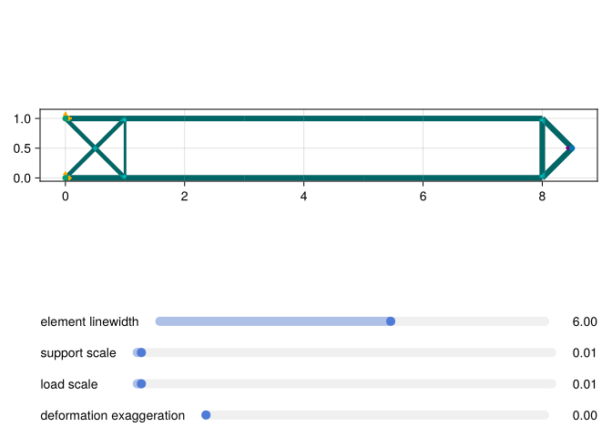

```julia
using Makie, CairoMakie

fig1 = visualize(problem; solver.u, topology=r1.minimizer, default_exagg_scale=0.0)
fig2 = visualize(problem; solver.u, topology=r2.minimizer, default_exagg_scale=0.0)
```